# 3. Discretized Simultaneous Non-negative Matrix Factrozation (`dsiNMF`)

Koki Tsuyuzaki

Laboratory for Bioinformatics Research, RIKEN Center for Biosystems Dynamics Research  
k.t.the-answer@hotmail.co.jp

2023-03-07

# Introduction

In this vignette, we consider approximating non-negative multiple matrices as a product of binary (or non-negative) low-rank matrices (a.k.a., factor matrices).

Test data is available from `toyModel`.

```r
library("dcTensor")
X <- dcTensor::toyModel("dsiNMF_Easy")
```

You will see that there are some blocks in the data matrices as follows.

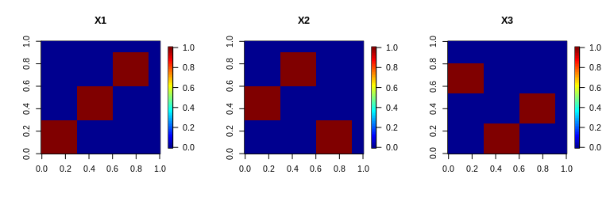

```r
suppressMessages(library("fields"))
layout(t(1:3))
image.plot(X[[1]], main="X1", legend.mar=8)
image.plot(X[[2]], main="X2", legend.mar=8)
image.plot(X[[3]], main="X3", legend.mar=8)
```

# Binary Simultaneous Matrix Factorization (BSMF)

Here, we consider the approximation of $K$ binary data matrices $X_{k}$ ($N \times M_{k}$) as the matrix product of $W$ ($N \times J$) and $V_{k}$ (J $M_{k}$):

$$X_{k} \approx W H_{k} \ \mathrm{s.t.}\ W,H_{k} \in \{0,1\}$$

This is the combination of binary matrix factorization (BMF (Z. et al. Zhang 2007)) and simultaneous non-negative matrix decomposition (siNMF (Badea 2008; S. et al. Zhang 2012; Yilmaz 2010; CICHOCK 2009)), which is implemented by adding binary regularization against siNMF.

For the details of arguments of dsiNMF, see `?dsiNMF`. After the calculation, various objects are returned by `dsiNMF`.

See also `siNMF` function of nnTensor package.

## Basic Usage

In BSMF, a rank parameter $J$ ($\leq \min(N, M)$) is needed to be set in advance. Other settings such as the number of iterations (`num.iter`) or factorization algorithm (`algorithm`) are also available. For the details of arguments of dsiNMF, see `?dsiNMF`. After the calculation, various objects are returned by `dsiNMF`. BSMF is achieved by specifying the binary regularization parameter as a large value like the below:

```r
set.seed(123456)
out_dsiNMF <- dsiNMF(X, Bin_W=1E+1, Bin_H=c(1E+1, 1E+1, 1E+1), J=3)
str(out_dsiNMF, 2)
```

```
## List of 6
##  $ W            : num [1:100, 1:3] 0.0479 0.0479 0.0479 0.0479 0.0479 ...
##  $ H            :List of 3
##   ..$ : num [1:300, 1:3] 0.00208 0.00206 0.00209 0.0021 0.00206 ...
##   ..$ : num [1:200, 1:3] 3.11e-244 1.18e-243 4.12e-244 5.19e-244 2.46e-243 ...
##   ..$ : num [1:150, 1:3] 0.997 0.997 0.997 0.997 0.997 ...
##  $ RecError     : Named num [1:101] 1.00e-09 1.24e+02 1.16e+02 1.11e+02 1.09e+02 ...
##   ..- attr(*, "names")= chr [1:101] "offset" "1" "2" "3" ...
##  $ TrainRecError: Named num [1:101] 1.00e-09 1.24e+02 1.16e+02 1.11e+02 1.09e+02 ...
##   ..- attr(*, "names")= chr [1:101] "offset" "1" "2" "3" ...
##  $ TestRecError : Named num [1:101] 1e-09 0e+00 0e+00 0e+00 0e+00 0e+00 0e+00 0e+00 0e+00 0e+00 ...
##   ..- attr(*, "names")= chr [1:101] "offset" "1" "2" "3" ...
##  $ RelChange    : Named num [1:101] 1.00e-09 5.59e-01 7.01e-02 3.87e-02 2.20e-02 ...
##   ..- attr(*, "names")= chr [1:101] "offset" "1" "2" "3" ...
```

The reconstruction error (`RecError`) and relative error (`RelChange`, the amount of change from the reconstruction error in the previous step) can be used to diagnose whether the calculation is converged or not.

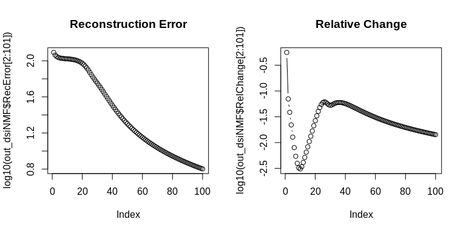

```r
layout(t(1:2))
plot(log10(out_dsiNMF$RecError[2:101]), type="b", main="Reconstruction Error")
plot(log10(out_dsiNMF$RelChange[2:101]), type="b", main="Relative Change")
```

The products of $W$ and $H_{k}$s show whether the original data marices are well-recovered by `dsiNMF`.

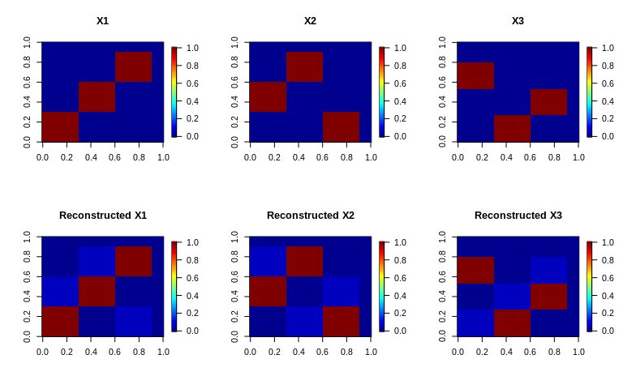

```r
recX <- lapply(seq_along(X), function(x){
  out_dsiNMF$W %*% t(out_dsiNMF$H[[x]])
})
layout(rbind(1:3, 4:6))
image.plot(X[[1]], main="X1", legend.mar=8)
image.plot(X[[2]], main="X2", legend.mar=8)
image.plot(X[[3]], main="X3", legend.mar=8)
image.plot(recX[[1]], main="Reconstructed X1", legend.mar=8)
image.plot(recX[[2]], main="Reconstructed X2", legend.mar=8)
image.plot(recX[[3]], main="Reconstructed X3", legend.mar=8)
```

The histograms of $H_{k}$s show that $H_{k}$s look binary.

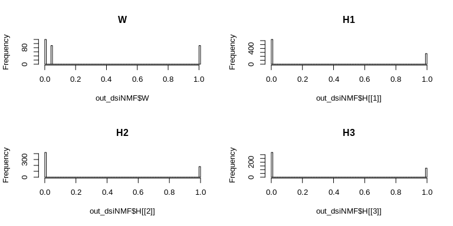

```r
layout(rbind(1:2, 3:4))
hist(out_dsiNMF$W, main="W", breaks=100)
hist(out_dsiNMF$H[[1]], main="H1", breaks=100)
hist(out_dsiNMF$H[[2]], main="H2", breaks=100)
hist(out_dsiNMF$H[[3]], main="H3", breaks=100)
```

# Semi-Binary Simultaneous Matrix Factorization (SBSMF)

Semi-Binary Simultaneous Matrix Factorization (SBSMF) is an extension of BSMF; we can select specific factor matrix (or matrices).

To demonstrate SBSMF, next we use non-negative matrices from the `nnTensor` package.

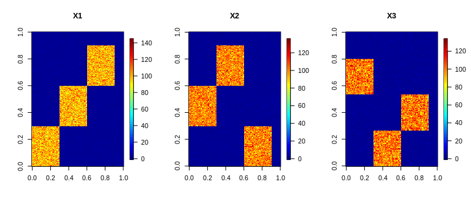

```r
suppressMessages(library("nnTensor"))
X2 <- nnTensor::toyModel("siNMF_Easy")
layout(t(1:3))
image.plot(X2[[1]], main="X1", legend.mar=8)
image.plot(X2[[2]], main="X2", legend.mar=8)
image.plot(X2[[3]], main="X3", legend.mar=8)
```

## Basic Usage

In SBSMF, a rank parameter $J$ ($\leq \min(N, M)$) is needed to be set in advance. Other settings such as the number of iterations (`num.iter`) or factorization algorithm (`algorithm`) are also available. For the details of arguments of dsiNMF, see `?dsiNMF`. After the calculation, various objects are returned by `dsiNMF`. SBSMF is achieved by specifying the binary regularization parameter as a large value like the below:

```r
set.seed(123456)
out_dsiNMF2 <- dsiNMF(X2, Bin_W=1E+2, J=3)
str(out_dsiNMF2, 2)
```

```
## List of 6
##  $ W            : num [1:100, 1:3] 0.0988 0.1006 0.1056 0.1023 0.1003 ...
##  $ H            :List of 3
##   ..$ : num [1:300, 1:3] 5.43e-10 3.89e-10 7.38e-10 2.05e-09 5.05e-10 ...
##   ..$ : num [1:200, 1:3] 1.46e-15 6.40e-15 6.54e-15 7.36e-15 2.28e-14 ...
##   ..$ : num [1:150, 1:3] 95.6 92.7 94 96.2 95.1 ...
##  $ RecError     : Named num [1:101] 1.00e-09 1.17e+04 1.14e+04 1.10e+04 1.08e+04 ...
##   ..- attr(*, "names")= chr [1:101] "offset" "1" "2" "3" ...
##  $ TrainRecError: Named num [1:101] 1.00e-09 1.17e+04 1.14e+04 1.10e+04 1.08e+04 ...
##   ..- attr(*, "names")= chr [1:101] "offset" "1" "2" "3" ...
##  $ TestRecError : Named num [1:101] 1e-09 0e+00 0e+00 0e+00 0e+00 0e+00 0e+00 0e+00 0e+00 0e+00 ...
##   ..- attr(*, "names")= chr [1:101] "offset" "1" "2" "3" ...
##  $ RelChange    : Named num [1:101] 1.00e-09 1.17e-01 2.89e-02 3.68e-02 1.26e-02 ...
##   ..- attr(*, "names")= chr [1:101] "offset" "1" "2" "3" ...
```

`RecError` and `RelChange` can be used to diagnose whether the calculation is converged or not.

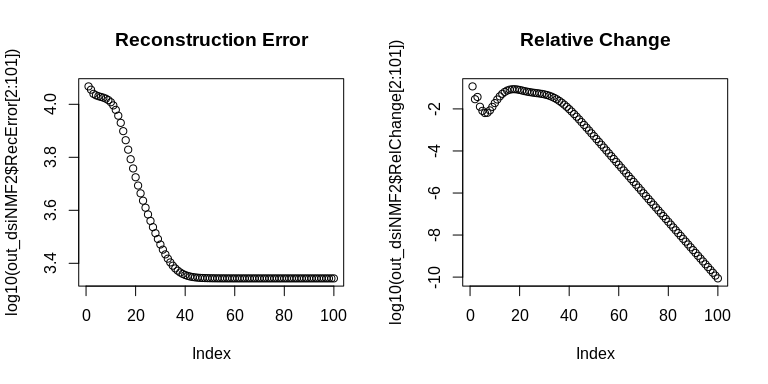

```r
layout(t(1:2))
plot(log10(out_dsiNMF2$RecError[2:101]), type="b", main="Reconstruction Error")
plot(log10(out_dsiNMF2$RelChange[2:101]), type="b", main="Relative Change")
```

The products of $W$ and $H_{k}$s show whether the original data is well-recovered by `dsiNMF`.

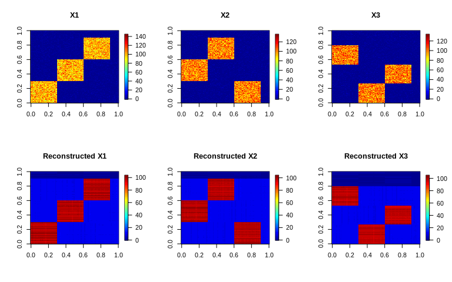

```r
recX <- lapply(seq_along(X2), function(x){
  out_dsiNMF2$W %*% t(out_dsiNMF2$H[[x]])
})
layout(rbind(1:3, 4:6))
image.plot(X2[[1]], main="X1", legend.mar=8)
image.plot(X2[[2]], main="X2", legend.mar=8)
image.plot(X2[[3]], main="X3", legend.mar=8)
image.plot(recX[[1]], main="Reconstructed X1", legend.mar=8)
image.plot(recX[[2]], main="Reconstructed X2", legend.mar=8)
image.plot(recX[[3]], main="Reconstructed X3", legend.mar=8)
```

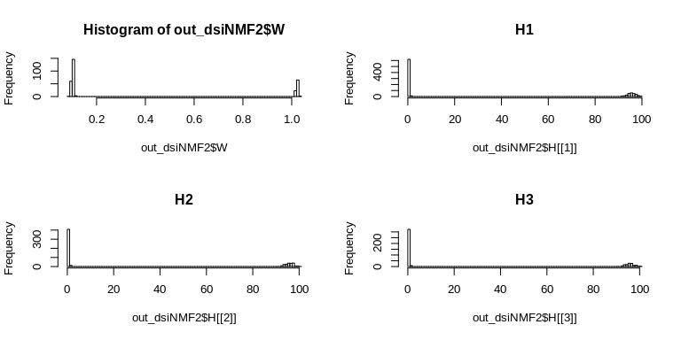

```r
layout(rbind(1:2, 3:4))
hist(out_dsiNMF2$W, breaks=100)
hist(out_dsiNMF2$H[[1]], main="H1", breaks=100)
hist(out_dsiNMF2$H[[2]], main="H2", breaks=100)
hist(out_dsiNMF2$H[[3]], main="H3", breaks=100)
```

# References

Badea, L. 2008. “Extracting Gene Expression Profiles Common to Colon and Pancreatic Adenocarcinoma Using Simultaneous Nonnegative Matrix Factorization.” *Pacific Symposium on Biocomputing*, 279–90.

CICHOCK, A. et al. 2009. *Nonnegative Matrix and Tensor Factorizations*. Wiley.

Yilmaz, Y. K. 2010. “Probabilistic Latent Tensor Factorization.” *IVA/ICA 2010*, 346–53.

Zhang, S. et al. 2012. “Discovery of Multi-Dimensional Modules by Integrative Analysis of Cancer Genomic Data.” *Nucleic Acids Research* 40(19): 9379–91.

Zhang, Z. et al. 2007. “Binary Matrix Factorization with Applications.” *ICDM 2007*, 391–400.